# 산업공학특론I_중간고사

정 휘준 (2023141277)

4/10/2024

### [중간고사 개요]

#### 1. 중간고사 답안 작성 및 제출 요령

- 모든 답안 도출 과정은 R 코드로 작성되어야 하며, 코드에는 분석 과정을 식별할 수 있도록 주석(#)으로 설명이 작성되어야 한다. (R 코드 없이 답만 적는 경우 오답 처리)
- 수강생 간 코드를 공유하거나 동일하게 작성하는 행위를 금지한다. (적발 시 진실의 방 소환 및 모두 0점으로 성적 반영)
- 특정한 문제에 대한 답안은 해당 문항에 대한 코드에 작성되어야 한다. (1번 문항에 대한 답을 2번 문항에 적는 경우 오답 처리)
- 답안은 Rmd 확장자로 보고서 제작이 가능하도록 제출하는 것을 원칙으로 하나, Markdown 실행이 어려운 경우 R 스크립트로 작성하되 채점이 가능하도록 문항 별로 스크립트를 작성하여야 한다.
- 중간고사 답안은 4월 10일 23시 59분까지 온라인 강의실 내 과제 및 평가 - 중간고사 탭에 제출하여야 하며, 4월 11일 자정 이후에는 제출이 불가하다. (이후 다른 경로를 통하여 제출 시 총점의 50%로 성적 반영)

#### 2. 데이터 설명

어느 의류 생산 공정에서는 재봉 (sewing), 마감 (finishing)으로 부서를 구성하여 공정을 운영하고 있으며, 공정의 생산성을 개선하기 위해 일별 공정 작업 관련 데이터를 수집하여 생산성에 영향을 미치는 요인을 분석하고자 한다. 데이터 분석에 활용하는 변수의 정보는 다음과 같다.

- date: 집계 날짜
- quarter: 한 달을 나눈 분기 (주)
- department: 부서
- day: 요일
- team: 부서별 투입 인원 수
- targeted_productivity: 당초에 목표한 생산성 점수
- over_time: 초과근무 (분)
- incentive: 성과급
- actual_productivity: 실제 생산성 점수

상기에 기술된 작성요령과 데이터를 기반으로 주어진 문제에 대한 분석 과정과 그에 따른 답안을 기술하시오.

### [중간고사 문항]

#### 1. 주어진 데이터에서 데이터 탐색 (EDA) 및 전처리를 수행하고, 결과를 시각화하시오. (10점)

- 활용하지 않는 변수 (date, smv, wip, idle_time, idle_men, no_of_style_change, no_of_workers)는 삭제할 것
- 시각화 시 범주형 변수는 막대그래프로, 연속형 변수는 히스토그램으로 표현할 것

```r
#Ignore Warning Message
options(warn = -1)

#Load Library
library(dplyr, verbose = F, warn.conflicts = F)  # For drop or select columns library
library(MASS, verbose = F, warn.conflicts = F) # "Fitdistr" Baseline library
library(fitdistrplus, verbose = F, warn.conflicts = F) # Fit distribution library
```

```r
library(knitr, verbose = F, warn.conflicts = F) # Printing Table library
library(kableExtra, verbose = F, warn.conflicts = F) # Table Styling library
library(FAdist) # For fitting 3 parameter distribution
library(flexsurv)
library(ggplot2)
```

```r
#Loading Data
dat <- read.csv("산업공학특론I_중간고사 데이터.csv")

#Select columns
df <- dplyr::select(dat, - c("date", "smv", "wip", "idle_time", "idle_men", "no_of_style_change", "no_of_workers"))

#Department has to be owned (finishing or sewing) but there is one more "finishing ". must to change "finishing " into "finishing".
#Department has to be owned "sewing" but there is "sweing". it must to be changed into "sewing".
df$department <- gsub("\\s+", "", df$department)
df$department <- gsub("sweing", "sewing", df$department)

#Actual productivity is probability value so, it cannot over 1.0. it changes into Mean.
df$actual_productivity <- replace(df$actual_productivity, which(df$actual_productivity>1.0), mean(df$actual_productivity))

#There is abnormal value in the incentive. This indices value is switch with "over_time" columns
indices <- which(df$incentive > 200)
temp <- as.integer(df$over_time[indices])
df$over_time[indices] <- df$incentive[indices]
df$incentive[indices] <- temp

#Column Factorization
df$quarter <- as.factor(df$quarter)
df$department <- as.factor(df$department)
df$day <- as.factor(df$day)
df$team <- as.factor(df$team)

#Change column names
new_column_names <- gsub("_", "", colnames(df)) # 밑줄(_) 삭제
new_column_names <- sapply(new_column_names, function(name) {
  # 맨 앞 글자를 대문자로 전환
  paste(toupper(substr(name, 1, 1)), substr(name, 2, nchar(name)), sep="")
})
colnames(df) <- new_column_names

#Summarize
summary(df)
```

```
##      Quarter        Department         Day           Team
##  Quarter1:360   finishing:506   Monday   :199   2      :109
##  Quarter2:335   sewing   :691   Saturday :187   8      :109
##  Quarter3:210                   Sunday   :203   1      :105
##  Quarter4:248                   Thursday :199   4      :105
##  Quarter5: 44                   Tuesday  :201   9      :104
##                                 Wednesday:208   10     :100
##                                                 (Other):565
##  Targetedproductivity    Overtime       Incentive      Actualproductivity
##  Min.   :0.0700       Min.   :    0   Min.   :  0.00   Min.   :0.2337
##  1st Qu.:0.7000       1st Qu.: 1440   1st Qu.:  0.00   1st Qu.:0.6503
##  Median :0.7500       Median : 3960   Median :  0.00   Median :0.7507
##  Mean   :0.7296       Mean   : 4580   Mean   : 25.68   Mean   :0.7263
##  3rd Qu.:0.8000       3rd Qu.: 6960   3rd Qu.: 50.00   3rd Qu.:0.8319
##  Max.   :0.8000       Max.   :25920   Max.   :138.00   Max.   :1.0000
##
```

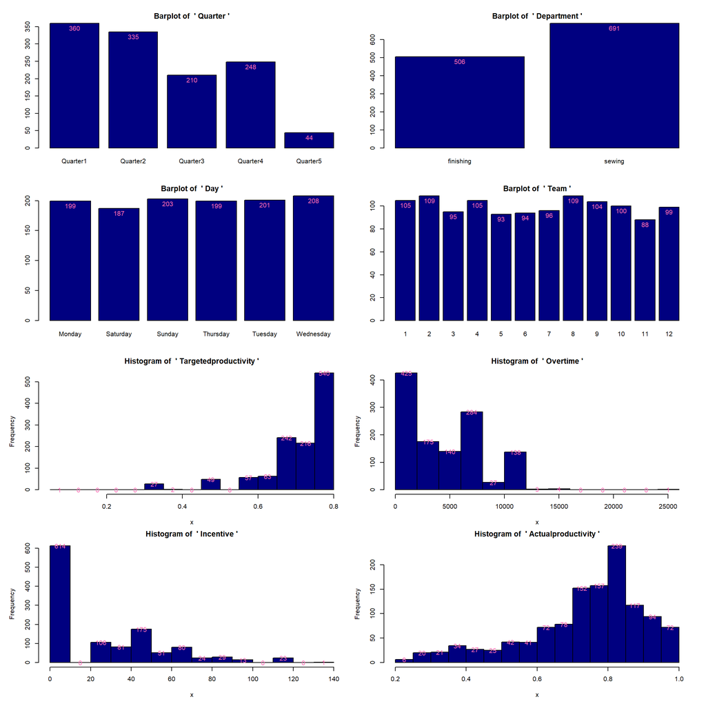

```r
#Plotting Data
visualize = function(x, title) {
  if(is.factor(x)) {
    freqs <- table(x)
    Bar <- barplot(freqs, col='navy', main=paste("Barplot of ", "'",title,"'"))
    text(x = Bar, y = freqs + max(freqs) * 0.01, labels = freqs, pos = 1, cex = 1, col='hotpink')
  }
  else {
    H <- hist(x, breaks=12, plot = FALSE)
    plot(H, col='navy', main=paste("Histogram of ", "'", title, "'"))
    mids <- H$mids
    counts <- H$counts
    text(x = mids, y = counts + max(counts) * 0.05, labels = counts, pos = 1, cex = 1, col='hotpink')
  }
}

par(mfrow=c(4,2), mar=c(4, 4, 2, 1), oma=c(1, 1, 1, 1))
for(i in 1:ncol(df)){
  visualize(x=df[,i], title=colnames(df)[i])
}
```

#### 2. 실제 생산성 점수 (actual_productivity)가 어떠한 분포를 따르는지 규명하기 위하여 여러 분포에 대한 MLE를 추정 및 비교하고, 최적 분포를 도출하시오. (15점)

- 여러 분포 (최소 2개 이상)에 대하여 MLE를 통하여 모수를 추정할 것
- 분포별 추정 결과 비교 시 적합도 평가 지표를 활용할 것
- 추정 결과에 따른 최적 분포를 도출하고, 그 근거를 제시할 것

```r
#Data
x <- df$Actualproductivity

#Distribution Negative Log-likelihood function
gamma_loglikelihood <- function(par, x){
  -sum(dgamma(x, shape=par[1], rate=par[2], log=T))
}

norm_loglikelihood <- function(par, x) {
  -sum(dnorm(x, mean=par[1], sd=par[2], log=T))
}

weib_loglikelihood <- function(par, x){
  -sum(dweibull(x, shape=par[1], scale=par[2], log=T))
}

exp_loglikelihood <- function(par, x){
  -sum(dexp(x, rate=par, log=T))
}

#Optimization MLE function each distribution
res_gamma <- optim(par = c(3, 6), fn = gamma_loglikelihood, x = x, control = list(type = 2))
res_norm <- optim(par = c(mean(x), var(x)), fn = norm_loglikelihood, x = x, control = list(type = 2))
res_weib <- optim(par = c(5, 1), fn = weib_loglikelihood, x = x, control = list(type = 2))
res_exp <- optim(par = 1, fn = exp_loglikelihood, x = x, method="L-BFGS-B", control = list(type = 1))

#Make Table of MLE Estimation and Choose Best Model
num_param <- c(2, 2, 2, 1)
idx <- c("Gamma", "Normal", "Weibull", "Exponential")
ll <- c(res_gamma$value, res_norm$value, res_weib$value, res_exp$value)
AIC <- -2 * ll + 2 * num_param
BIC <- -2 * ll + log(length(x)) * num_param
est <- rbind(res_gamma$par, res_norm$par, res_weib$par, c(res_exp$par, NaN))
Res <- data.frame(
  Log_likelihood = ll,
  AIC = AIC,
  BIC = BIC,
  Estimated_Parameter = est
)
rownames(Res) <- idx

#Print distribution MLE value and parameters
kable(Res, "html") %>%
  kable_styling(bootstrap_options = c("striped", "hover"), full_width = F)
```

|  | Log_likelihood | AIC | BIC | Estimated_Parameter.1 | Estimated_Parameter.2 |
| --- | --- | --- | --- | --- | --- |
| Gamma | -323.3480 | 650.6960 | 660.8712 | 14.7701760 | 20.3368090 |
| Normal | -446.0236 | 896.0471 | 906.2223 | 0.7262261 | 0.1666955 |
| Weibull | -504.6217 | 1013.2435 | 1023.4186 | 5.5241853 | 0.7882659 |
| Exponential | 814.1628 | -1626.3256 | -1621.2380 | 1.3768947 | NaN |

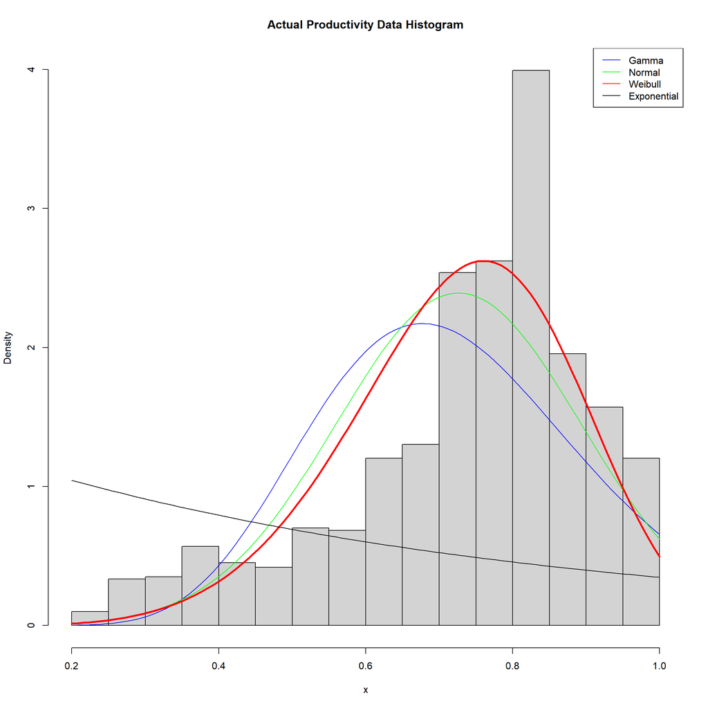

```r
#Visualization Rationale of Distribution
hist(x, breaks=20, prob=T, main='Actual Productivity Data Histogram')
curve(dgamma(x, shape=res_gamma$par[1] ,rate=res_gamma$par[2]), col='blue', add=T)
curve(dnorm(x, mean=res_norm$par[1], sd=res_norm$par[2]), col='green', add=T)
curve(dweibull(x, shape=res_weib$par[1], scale=res_weib$par[2]), col='red', add=T, lwd=3)
curve(dexp(x, rate=res_exp$par), col='black', add=T)
legend('topright', legend = c('Gamma', 'Normal', 'Weibull', 'Exponential'), col=c('blue', 'green', 'red', 'black'), lty=1)
```

```r
#Choose Best Model
cat("The Best Model by BIC value")
```

```
## The Best Model by BIC value
```

```r
max_bic_idx <- which.max(Res$BIC)
kable(Res[max_bic_idx,], "html") %>%
  kable_styling(bootstrap_options = c("striped", "hover"), full_width = F)
```

|  | Log_likelihood | AIC | BIC | Estimated_Parameter.1 | Estimated_Parameter.2 |
| --- | --- | --- | --- | --- | --- |
| Weibull | -504.6217 | 1013.243 | 1023.419 | 5.524185 | 0.7882659 |

#### 3. 2. 에서 도출된 최적 분포를 기준으로 MLE 추정 결과를 시각화하고 이를 해석하시오. (10점)

- 시각화의 경우 실제 데이터의 분포와 MLE를 모수로 가지는 분포의 비교가 가능하도록 도시할 것
- 단순 도시가 아닌 도시 결과에 대한 해석 결과를 설명하고, 결론을 도출할 것

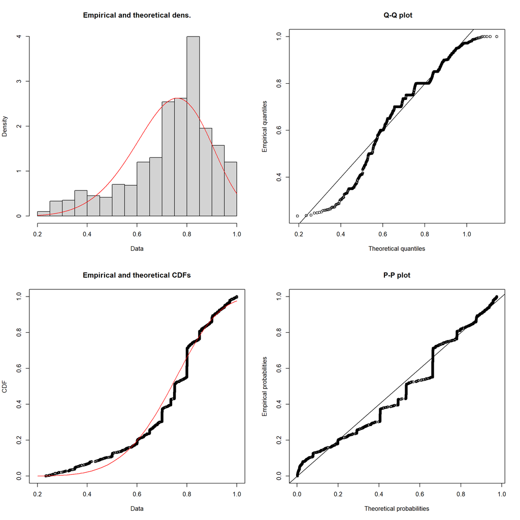

```r
#Plot and Fit Actual Productivity with Best Distribution (= Weibull)
plot(fitdist(x, "weibull"))
```

```r
kable(des, "html") %>%
  kable_styling(bootstrap_options = c("striped", "hover"), full_width = F)
```

[output not shown]

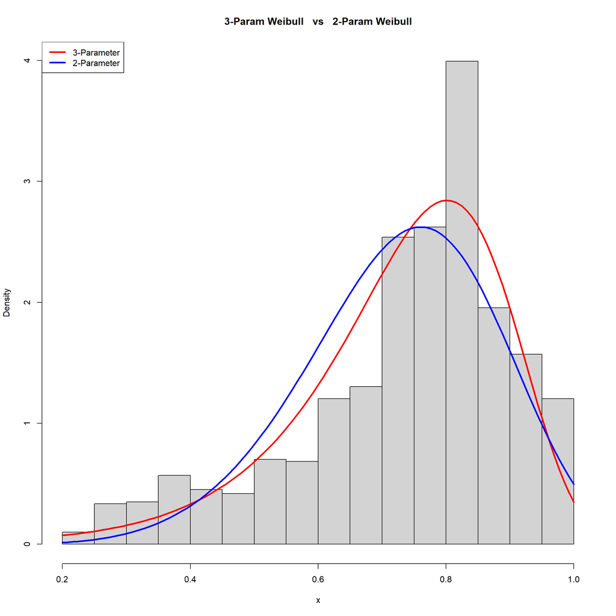

```r
#Fitting Data with 3-Parameter Weibull Distribution
weib3_loglikelihood <- function(par, x){
  -sum(FAdist::dweibull3(x, shape=par[1], scale=par[2], thres=par[3], log=T))
}
res_weib3 <- optim(par = c(5, 1, 0), fn = weib3_loglikelihood, x = x, control = list(type = 2))

#Visualization Rationale
hist(x, breaks=15, prob=T, main='3-Param Weibull   vs   2-Param Weibull')
curve(FAdist::dweibull3(x, shape=res_weib3$par[1], scale=res_weib3$par[2], thres=res_weib3$par[3]), add=T, col='red', lwd=3)
curve(dweibull(x, shape=res_weib$par[1], scale=res_weib$par[2]), col='blue', add=T, lwd=3)
legend('topleft', legend = c('3-Parameter', '2-Parameter'), col=c('red', 'blue'), lwd=3)
```

```r
#Create Table for Comapre with (2-param Weib, 3-param Weib)
weib_param <- c(3, 2)
idx_w <- c("3-Parameter Weibull", "2-Parameter Weibull")
ll_w <- c(res_weib3$value, res_weib$value)
AIC_w <- -2 * ll_w + 2 * weib_param
BIC_w <- -2 * ll_w + log(length(x)) * weib_param
est_w <- rbind(res_weib3$par, c(res_weib$par, NaN))
Res_w <- data.frame(
  Log_likelihood = ll_w,
  AIC = AIC_w,
  BIC = BIC_w,
  Shape = est_w[,1],
  Scale = est_w[,2],
  Threshold = est_w[,3]
)
rownames(Res_w) <- idx_w

kable(Res_w, "html") %>%
  kable_styling(bootstrap_options = c("striped", "hover"), full_width = F)
```

|  | Log_likelihood | AIC | BIC | Shape | Scale | Threshold |
| --- | --- | --- | --- | --- | --- | --- |
| 3-Parameter Weibull | -554.0620 | 1114.124 | 1129.387 | 3.863848e+07 | 4.997949e+06 | -4997948 |
| 2-Parameter Weibull | -504.6217 | 1013.243 | 1023.419 | 5.524185e+00 | 7.882659e-01 | NaN |

```r
#Choose Best Model
cat("The Best Model by BIC value")
```

```
## The Best Model by BIC value
```

```r
max_bic_idx_w <- which.max(Res_w$BIC)
kable(Res_w[max_bic_idx_w,], "html") %>%
  kable_styling(bootstrap_options = c("striped", "hover"), full_width = F)
```

|  | Log_likelihood | AIC | BIC | Shape | Scale | Threshold |
| --- | --- | --- | --- | --- | --- | --- |
| 3-Parameter Weibull | -554.062 | 1114.124 | 1129.387 | 38638481 | 4997949 | -4997948 |

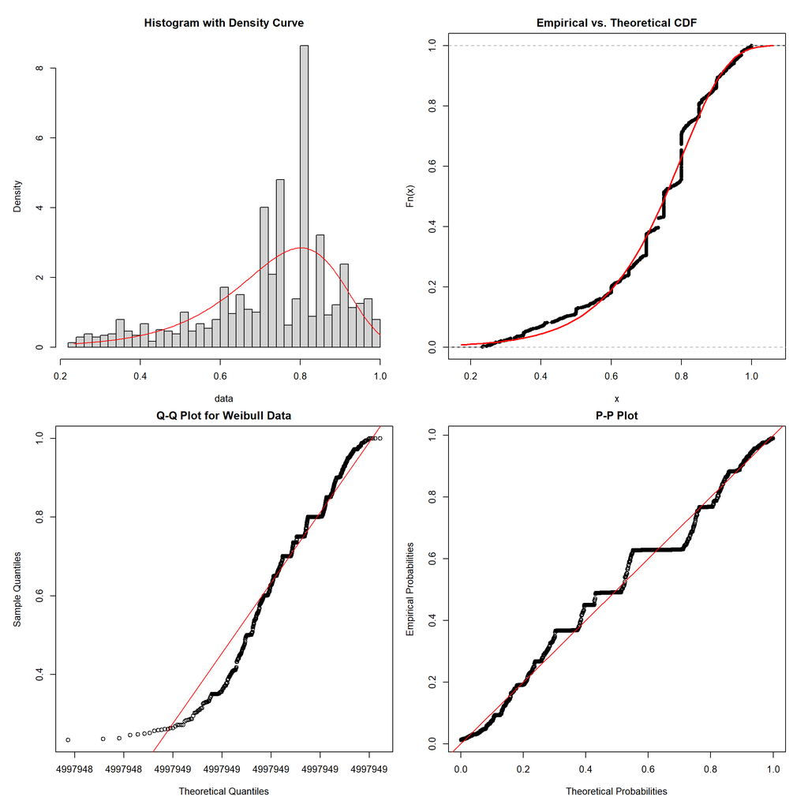

```r
data <- df$Actualproductivity

shape <- res_weib3$par[1]
scale <- res_weib3$par[2]
location <- res_weib3$par[3]

par(mfrow=c(2,2), mar=c(4, 4, 2, 1), oma=c(1, 1, 1, 1))
# Plot Histogram with Theoretical Density
hist(data, breaks = 30, probability = TRUE, main = "Histogram with Density Curve")
density_values <- dweibull3(seq(min(data), max(data), length.out = 300), shape = shape, scale = scale, thres = location)
lines(seq(min(data), max(data), length.out = 300), density_values, col = 'red')

# Plot CDF
ecdf_data <- ecdf(data) # Empirical CDF
plot(ecdf_data, main = "Empirical vs. Theoretical CDF")
curve(pweibull3(x, shape = shape, scale = scale, thres = location), add = TRUE, col = 'red', lwd=2)

# Generate Q-Q Plot
qqplot(qweibull(ppoints(length(data)), shape, scale, location), data,
       main = "Q-Q Plot for Weibull Data",
       xlab = "Theoretical Quantiles",
       ylab = "Sample Quantiles")
qqline(data, distribution = function(p) qweibull(p, shape, scale, location), col = "red")

# Generate P-P Plot
ppplot <- function(data, dist, params) {
  theoretical_p <- ppoints(length(data))
  sample_p <- sort(pweibull3(data, params[1], params[2], params[3]))
  plot(theoretical_p, sample_p, main = "P-P Plot",
       xlab = "Theoretical Probabilities", ylab = "Empirical Probabilities")
  abline(0, 1, col = "red")
}
ppplot(data, "weibull", c(shape, scale, location))
```